# cimetiere

B. Maranget

12/06/2023

# 1 Objet

identification tombes du cimetière

Sous Qgis, on crée les polygones des sépultures et un chemin qui permet de les numéroter.

on extrait les sommets du chemin afin de pouvoir récupérer les allées dont on garde le sens.

on intersecte le chemin et les sépultures afin de récupérer les pts sépultures.

puis on replace les sépultures sur les allées et on calcule la distance à partir de chaque point zéro de l’allée.

Remarque 1

Simplification : éviter la phase allée on intersecte, on numérote tous les centroïdes et on supprime les centroides qui n’intersectent

le problème est que l’indexation n’est pas conservée (testé sous Qgis et R)

Remarque 2

Parfois le dessin s’avère complexe, donc on numérote les allées cf section AE la numérotation suit bien l’ordre de création des chemins et correspond au fid.

Du coup, on traite section par section quelque soit le nombre d’allée.

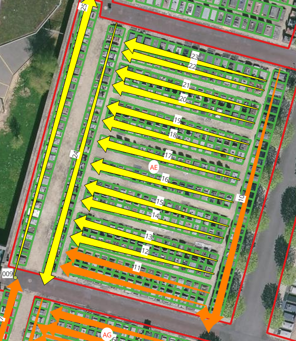

```r
library(sf)
```

```r
library(mapsf)
#library(rgdal)
```

# 2 Chemin data et data

Tout est dans le projet R

```r
chemin <- st_read("../data/cimetiere.gpkg", "chemin")
requiem <- st_read("../data/cimetiere.gpkg", "requiem") # le dessin des sépultures
section <- st_read("../data/cimetiere.gpkg", "section")
```

# 3 Prétraitement : du chemin au point de départ allée

## 3.1 Autour du chemin

### 3.1.1 Extraction des sommets sous R : recherche

st_reverse points devient ligne st_node ajoute des noeuds aux intersections … tout simplement st_cast

### 3.1.2 Identification

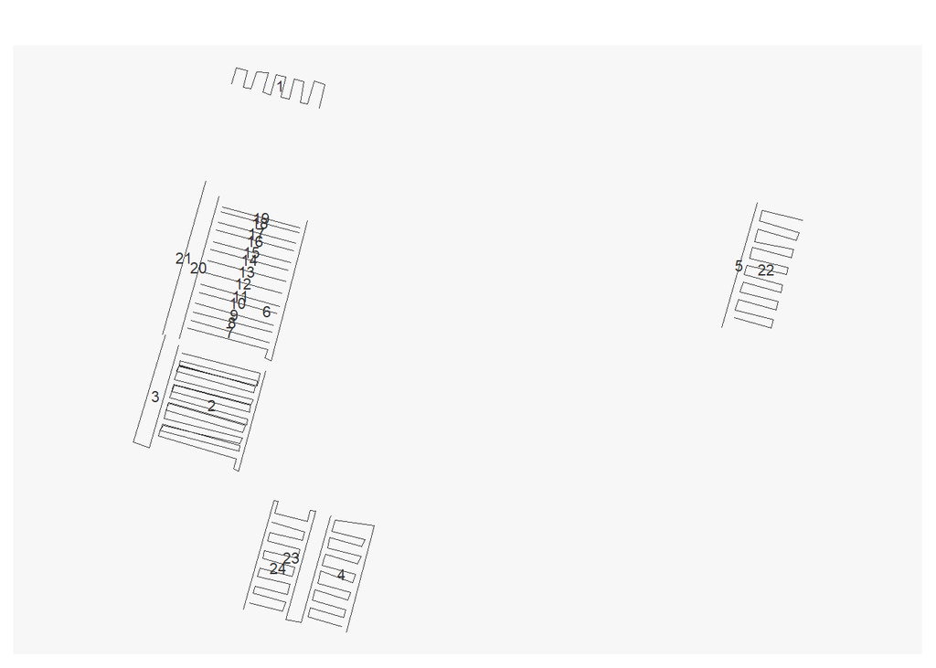

```r
mf_map(chemin)
chemin$num <- rownames(chemin)
mf_label(chemin, var = "num")
```

### 3.1.3 Lien section chemin

Permet de vérfier le nombre de chemins par section, Sans doute va-t-il falloir faire un traitement section par section.

```r
chemin <- st_intersection(chemin, section)
chemin
```

```
## Simple feature collection with 24 features and 2 fields
## Geometry type: GEOMETRY
## Dimension:     XY
## Bounding box:  xmin: 662123.2 ymin: 6866840 xmax: 662314.7 ymax: 6867006
## Projected CRS: RGF93 v1 / Lambert-93
## First 10 features:
##    num sections                           geom
## 5    5        S LINESTRING (662301.4 686696...
## 22  22        S LINESTRING (662294.8 686693...
## 4    4        L MULTILINESTRING ((662180.7 ...
## 23  23       AH LINESTRING (662150.5 686684...
## 24  24       AH LINESTRING (662158.9 686687...
## 2    2       AG MULTILINESTRING ((662157 68...
## 3    3       AG LINESTRING (662131.4 686692...
## 6    6       AE MULTILINESTRING ((662169.3 ...
## 7    7       AE LINESTRING (662158.1 686692...
## 8    8       AE LINESTRING (662158.8 686692...
```

### 3.1.4 choix du chemin

```r
chemin <- chemin [chemin$sections == 'AE',]
```

### 3.1.5 point chemin

```r
# caster un chemin en pt permet de garder l'indexation à chaque vertex
ptChemin <- st_cast(chemin, "POINT")
ptChemin$num <- rownames(ptChemin)
```

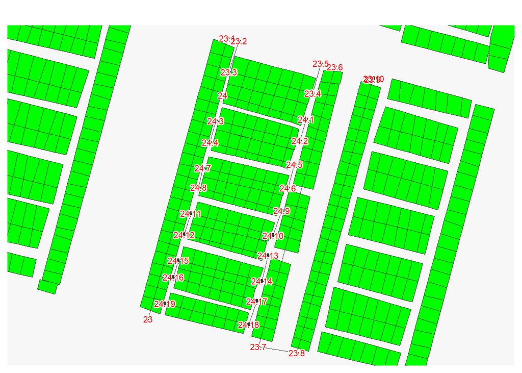

```r
mf_init(chemin)
mf_map(requiem, add = T, col = "green")
mf_map(chemin, add = T)
mf_map(ptChemin, add = T)
mf_label(ptChemin, var ="num", col= "red", halo = T)
```

Chemins et points correspondent normalement, l’ordre des points chemin est conservé

Chaque chemin commence par un numéro sans point (propriété qui sera utilisée avec un grep)

## 3.2 pt sépulture

### 3.2.1 Création du point : intersection chemin - tombe + centroid

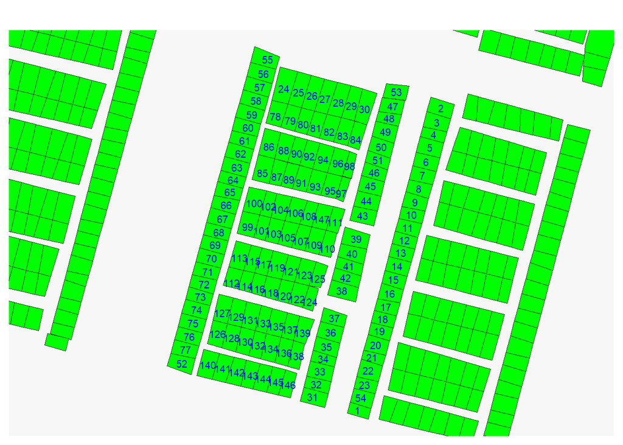

```r
ptSep <- st_centroid(st_intersection(requiem$geom, chemin))
ptSep <- st_as_sf(ptSep)
ptSep$num <- rownames(ptSep)
mf_init(chemin)
mf_map(requiem, add = T, col = "green")
mf_label(ptSep, var = "num",col = "blue")
```

Le ptSep (intersection chemin / sep) ne permet pas d’indenter.

Donc, on va calculer le pt origine pour chaque allée de sépulture et utiliser la distance.

## 3.3 l’allée

### 3.3.1 repérage des lignes allée avec les points de départ

combien d’allées ? on compte de visu puis par le calcul. cas AH = 14, calcul 15.5 donc 3 pts en trop solution : on calcule les lg qui ne sont pas dans les sép.

### 3.3.2 constitution des allees

faire un segment, il n’est valide que s’il intersecte et s’il n’ y a un pt dans le pt2

```r
lg <- NULL
segment <- NULL
faireSegment <- function(pt){
  segment <- st_cast(st_union(ptChemin$geom [pt], ptChemin$geom [pt+1]), "LINESTRING")
  segment <- st_as_sf(segment)
  # test sur validité segment
  if (
     st_is_valid(segment$x)==TRUE && !is.na(st_is_valid(segment$x))
     # pb st_is_valid peut renvoyer NA
  ){
    testInter  <- length(st_intersection(segment$x, requiem$geom)) > 1
    # une seule intersection n'est pas suffisante
   print(paste0("inter : ",testInter))
    if(testInter==TRUE){
      testGrep <- length (grep("\\.", ptChemin$num [pt+1])) == 1
    #print(paste0("grep :", testGrep))
      if (testGrep == TRUE){
      segment$num <- pt
      return(segment)
    }
  }
  }
}
# pour éviter pb liste, on fait boucle
for (pt in 1:(length(ptChemin$num)-1)) {
    print(pt)
    lg <- rbind(lg,faireSegment(pt))
}
```

```
## [1] 1
## [1] "inter : TRUE"
## [1] 2
## [1] "inter : FALSE"
## [1] 3
## [1] "inter : FALSE"
## [1] 4
## [1] "inter : TRUE"
## [1] 5
## [1] "inter : FALSE"
## [1] 6
## [1] "inter : FALSE"
## [1] 7
## [1] "inter : TRUE"
## [1] 8
```

[output cut: 45 more lines]

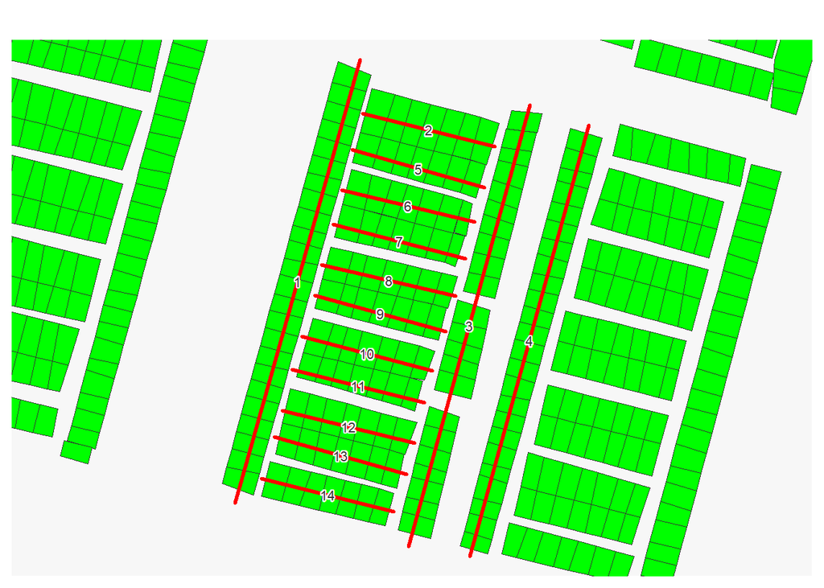

```r
lg$num <- rownames(lg)
# verif graphique
mf_init(lg)
mf_map(requiem, add = T, col = "green")
mf_map (lg, col = "red", lwd = 3, add = T)
mf_label(lg, var = "num", halo = T)
```

### 3.3.3 Récupération de l’allée du point (st_within)

dans le cas où il y avait un chemin par allée, on recopie chemin et allee

```r
# bizarre les pts n'appartiennent pas à la lg
st_intersection(ptSep, lg)
```

```
## Simple feature collection with 0 features and 2 fields
## Bounding box:  xmin: NA ymin: NA xmax: NA ymax: NA
## Projected CRS: RGF93 v1 / Lambert-93
## [1] num   num.1 x
## <0 lignes> (ou 'row.names' de longueur nulle)
```

```r
st_touches(ptSep, lg)
```

```
## Sparse geometry binary predicate list of length 147, where the
## predicate was `touches'
## first 10 elements:
##  1: (empty)
##  2: (empty)
##  3: (empty)
##  4: (empty)
##  5: (empty)
##  6: (empty)
##  7: (empty)
##  8: (empty)
##  9: (empty)
##  10: (empty)
```

```r
st_contains(ptSep, lg)
```

```
## Sparse geometry binary predicate list of length 147, where the
## predicate was `contains'
## first 10 elements:
##  1: (empty)
##  2: (empty)
##  3: (empty)
##  4: (empty)
##  5: (empty)
##  6: (empty)
##  7: (empty)
##  8: (empty)
##  9: (empty)
##  10: (empty)
```

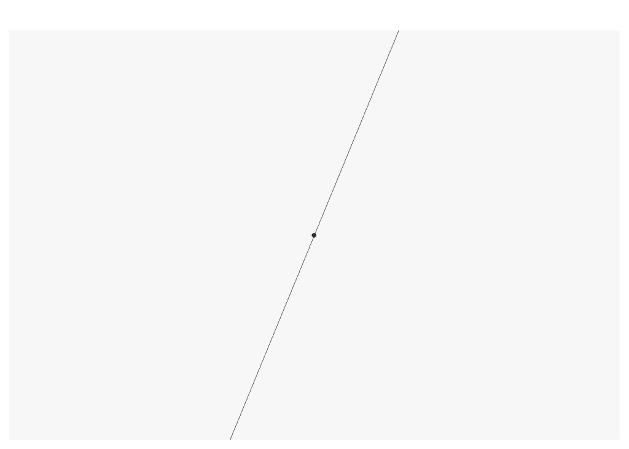

```r
# necessite d'y mettre une distance
# attention cas AE, les allées sont déjà faites
accroch <- st_is_within_distance(ptSep, lg , 1)
mf_map(ptSep [1,])
mf_map(lg [4,], add = T)
```

```r
lg[4,]
```

```
## Simple feature collection with 1 feature and 1 field
## Geometry type: LINESTRING
## Dimension:     XY
## Bounding box:  xmin: 662167.4 ymin: 6866843 xmax: 662176 ymax: 6866874
## Projected CRS: RGF93 v1 / Lambert-93
##   num                              x
## 4   4 LINESTRING (662167.4 686684...
```

```r
# verif du chiffre des derniers ptSep
tail(unlist(accroch))
```

```
## [1] 14 14 14 14 14  8
```

```r
# verif du nombre
# verif toutes les sépultures liées à une allée
serie <- sapply(accroch, length)
# test doit être vide
test <- which(serie == 0)
# rajout champs de l'allee dans le ptSep
accroch <- unlist(accroch)
ptSep$allee <- accroch
ptSep
```

```
## Simple feature collection with 147 features and 2 fields
## Geometry type: POINT
## Dimension:     XY
## Bounding box:  xmin: 662150.9 ymin: 6866844 xmax: 662175.6 ymax: 6866877
## Projected CRS: RGF93 v1 / Lambert-93
## First 10 features:
##                           x num allee
## 1  POINT (662167.7 6866844)   1     4
## 2  POINT (662175.6 6866873)   2     4
## 3  POINT (662175.3 6866872)   3     4
## 4  POINT (662174.9 6866870)   4     4
## 5  POINT (662174.6 6866869)   5     4
## 6  POINT (662174.2 6866868)   6     4
## 7  POINT (662173.9 6866866)   7     4
## 8  POINT (662173.5 6866865)   8     4
## 9  POINT (662173.2 6866864)   9     4
## 10 POINT (662172.8 6866863)  10     4
```

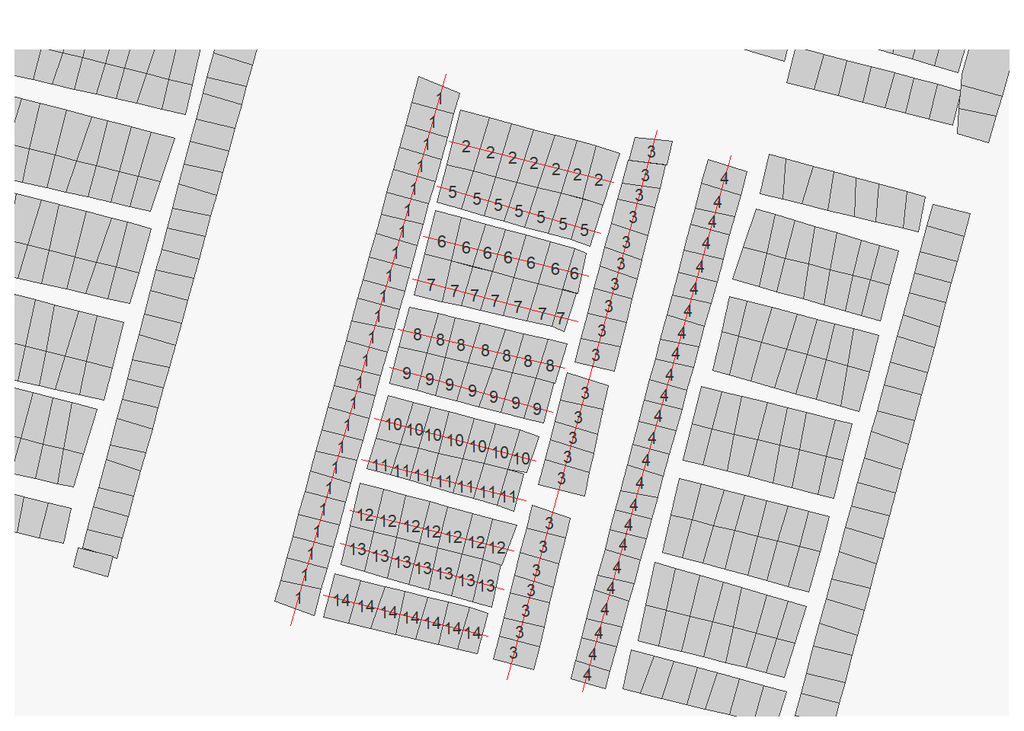

```r
# pb -1 pt Se
mf_init(ptChemin)
mf_map(requiem, add = T)
mf_map(lg, col = "red",add = T)
mf_label(ptSep, var ="allee")
```

# 4 Mesurer la distance pt sepulture - pt départ allée

## 4.1 Vérifications

### 4.1.1 verif nb de tombes par allée

Cela permet un contrôle rapide

```r
table(unlist(accroch))
```

```
##
##  1  2  3  4  5  6  7  8  9 10 11 12 13 14
## 24  7 22 24  7  7  7  7  7  7  7  7  7  7
```

### 4.1.2 Verif que les points ne sont pas ordonnés

C’est quelque chose de si troublant que l’on refait la verif à chaque fois !

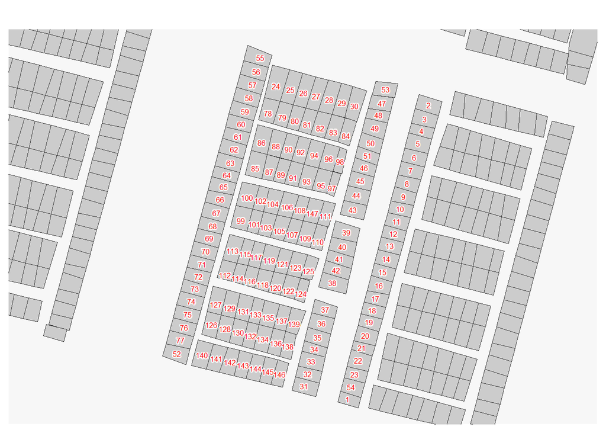

```r
tmp  <- unlist(accroch)
ptSep$num <- rownames(ptSep)
mf_init(chemin)
mf_map(requiem, add = T)
mf_label(ptSep, var = "num", col = "red", halo = T, cex= 0.5,overlap = T, add = T)
```

## 4.2 Mesure de la distance entre le pt 0 de l’allée et le pt Sepulture

Il faut que les ptSep et les pt aient une variable commune

### 4.2.1 variable pt

définition des ptLg de départ

```r
ptLg <- st_cast(lg, "POINT")
ptLg$num <- rownames(ptLg)
# on supprime les pts arrivées
str(ptLg)
```

```
## Classes 'sf' and 'data.frame':   28 obs. of  2 variables:
##  $ num: chr  "1" "1.1" "2" "2.1" ...
##  $ x  :sfc_POINT of length 28; first list element:  'XY' num  662150 6866847
##  - attr(*, "sf_column")= chr "x"
##  - attr(*, "agr")= Factor w/ 3 levels "constant","aggregate",..: NA
##   ..- attr(*, "names")= chr "num"
```

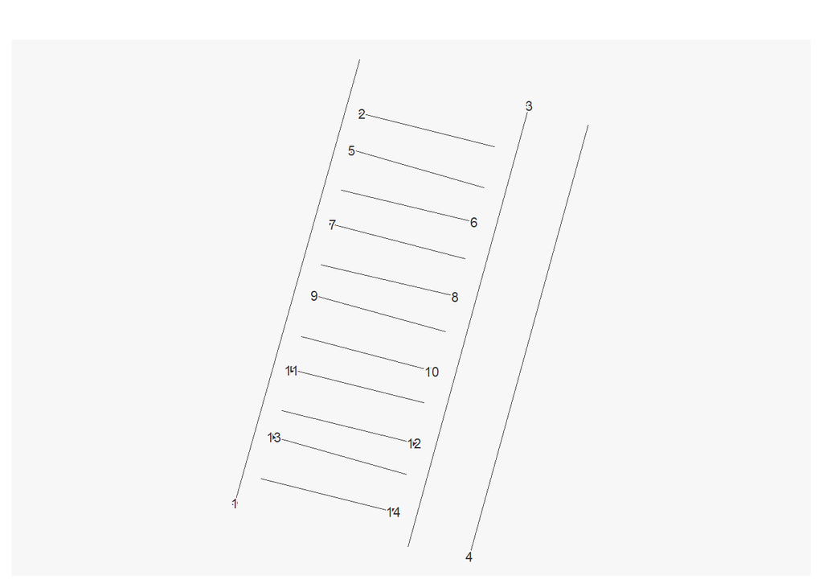

```r
ptLg <- ptLg [-grep("\\.",ptLg$num),]
# mettre en numérique
ptLg$num <- as.integer(ptLg$num)
# vérification graphique
mf_map(lg)
mf_map(ptLg, add =T)
mf_label(ptLg, var= "num", halo = T, add = T)
```

Donc, on a ptChemin, ptSep, ptLg

On prend les points lg et on mesure 1 à 1

```r
nb <- 1
# fonction pour classer les pts en fonction distance
mesurer <- function (nb){
  selSep <-  ptSep [ptSep$allee == nb,]
  selLg <- ptLg [ptLg$num == nb,]
  mat <- st_distance(selLg, selSep )
  mat
  dist <- as.vector (mat)
  dist
  selSep$dist <- dist
  selSep <- selSep [order(selSep$dist),]
  selSep
  seq <- (1:length(selSep$dist))
  selSep$num  <- seq
  selSep
  selSep <- selSep
  return(selSep)
}
# boucle car la liste difficile à manipuler
res <- NULL
i <- 1
cpt <- 0
for (i in min(ptLg$num):max(ptLg$num)){
  print(paste0(i, " et ",cpt))
  tmp <- mesurer (i)
  # compteur pour ordre des tombes sur la section
  tmp$num2 <- tmp$num+cpt
  cpt <- max(tmp$num)+cpt
  res <- rbind(tmp, res)
}
```

```
## [1] "1 et 0"
## [1] "2 et 24"
## [1] "3 et 31"
## [1] "4 et 53"
## [1] "5 et 77"
## [1] "6 et 84"
## [1] "7 et 91"
## [1] "8 et 98"
## [1] "9 et 105"
## [1] "10 et 112"
## [1] "11 et 119"
## [1] "12 et 126"
## [1] "13 et 133"
## [1] "14 et 140"
```

[figure not shown]

```r
# verif carto
mf_init(chemin)
mf_map(requiem, add = T)
mf_label(res, var = "num2")
```

```r
st_write(res, "../data/cimetiere.gpkg", "ptSepultureID", delete_layer = F, append=T)
```

```
## Updating layer `ptSepultureID' to data source `../data/cimetiere.gpkg' using driver `GPKG'
## Updating existing layer ptSepultureID
## Writing 147 features with 4 fields and geometry type Point.
```

# 5 intégration dans le dessin des tombes

```r
res
```

```
## Simple feature collection with 147 features and 4 fields
## Geometry type: POINT
## Dimension:     XY
## Bounding box:  xmin: 662150.9 ymin: 6866844 xmax: 662175.6 ymax: 6866877
## Projected CRS: RGF93 v1 / Lambert-93
## First 10 features:
##     num allee      dist num2                        x
## 146   1    14 0.9030994  141   POINT (662161 6866846)
## 145   2    14 2.0935230  142 POINT (662159.9 6866847)
## 144   3    14 3.3376827  143 POINT (662158.7 6866847)
## 143   4    14 4.6153534  144 POINT (662157.4 6866847)
## 142   5    14 5.9250009  145 POINT (662156.2 6866848)
## 141   6    14 7.2966192  146 POINT (662154.8 6866848)
## 140   7    14 8.7572821  147 POINT (662153.4 6866848)
## 126   1    13 1.0593690  134 POINT (662154.3 6866851)
## 128   2    13 2.4561218  135 POINT (662155.7 6866851)
## 130   3    13 3.8017475  136   POINT (662157 6866851)
```

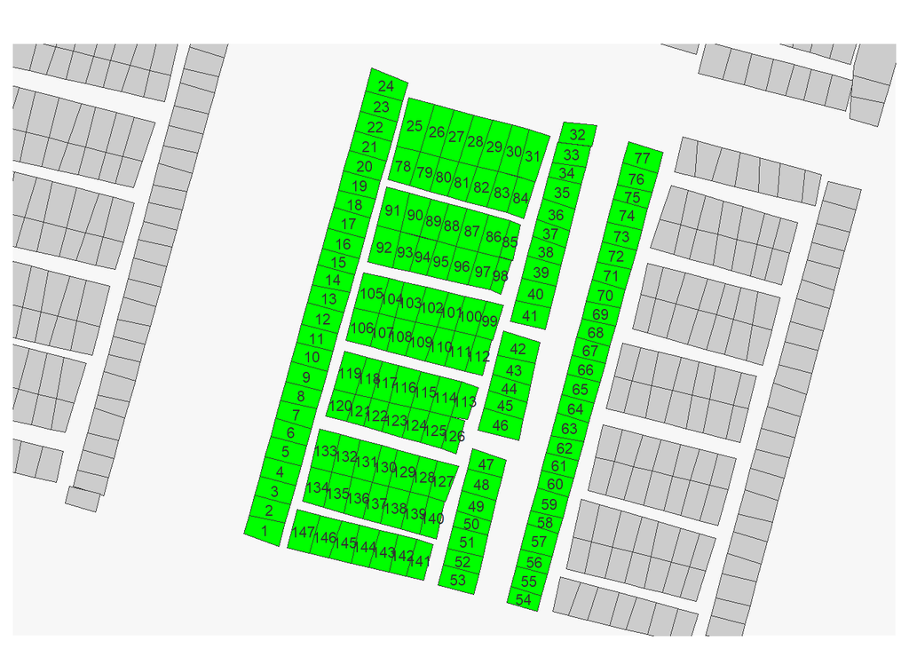

```r
jointureSpatiale <- st_within(res [,c("num2")], requiem, sparse = T)
lg <- unlist(jointureSpatiale)
res$lg <- lg
res <- st_drop_geometry(res)
requiem$lg <- rownames(requiem)
joint <- merge(requiem, res, by = "lg")
mf_init(chemin)
mf_map(requiem, add = T)
mf_map(joint, col="green", add = T)
mf_label(joint, var = "num2")
```

# 6 shape final

```r
joint
joint <- joint [order(joint$alleeL, joint$num),]
joint$lg <- seq(1:39)
joint
joint$E_ID <- paste0("bondy@",joint$lg)
joint$ALLEE <- joint$alleeL
joint$DIVISION <- "AA"
joint$EMPLACEMEN <- joint$num
st_write(joint [, c("E_ID", "Text", "DIVISION", "SECTION", "ALLEE", "EMPLACEMEN")],"../data/bondy.shp")
```

[output not shown]

# 7 Simplification

Utilisation d’un graphe ?